# computational_musicology

Daria Koppes

8-2-2021

The corpus consists of three of my own wrapped Spotify playlists, from the years 2018, 2019 and 2020. I chose this corpus because I want to investigate how my music style has evolved over the last three years. Did it change much or did my type of music style stay the same? Can you tell looking at the kind of music I was listening to what kind of year I generally had. 2019 for example was a good year for me and 2020 a more harder year, is that reflected in the music?

Comparison points would be artists and different music styles. I expect some artists to come back each year because I have been listening to them for a while now, e.g Imagine Dragons. Also when I travel I tend to be listening to more foreign music, so I expect 2018 and 2019 to have more Spanish/Portuguese/French artists in them than 2020 for example. I’m unsure if my music type/ style has significantly changed over the past three years but I am curious to look into it.

The strength of the corpus is that it contains a significant amount of representative songs and especially for 2019 and 2020 I recognize all the numbers in it. For 2018 however I notice that some songs in the wrapped playlist I have never listened to. I do not know how they got in my wrapped playlist. For example: Pastempomat sang by Dawid Pdsiadlo is a polish song and I am certain that I never listened to this song or any other polish song. In 2019 I was pretty obsessed with Billie Eilish so it is typical to see that 20 of the 100 songs in my wrapped playlist are by her.

```r
eighteen <- get_playlist_audio_features("", "37i9dQZF1EjuRTGXCnqj3q")
nineteen <- get_playlist_audio_features("", "37i9dQZF1Ethn3c8yyjsG9")
twenty <- get_playlist_audio_features("", "37i9dQZF1EM1eb9t3OIKaB")
billie <- get_playlist_audio_features("", "7L8fVkNZIHQ38k0hkcJkVo")
```

```r
combined <-
  bind_rows(
    eighteen %>% mutate(category = "Wrapped playlist 2018"),
    nineteen %>% mutate(category = "Wrapped playlist 2019"),
    twenty %>% mutate(category = "Wrapped playlist 2020")
  )

billie <-
  bind_rows(
        nineteen %>% mutate(category = "Wrapped playlist 2019"),
    billie %>% mutate(category = "Billie Eilish")
  )
```

Week 2: The first visualisations

First a histogram comparing the energy in the songs over the years.

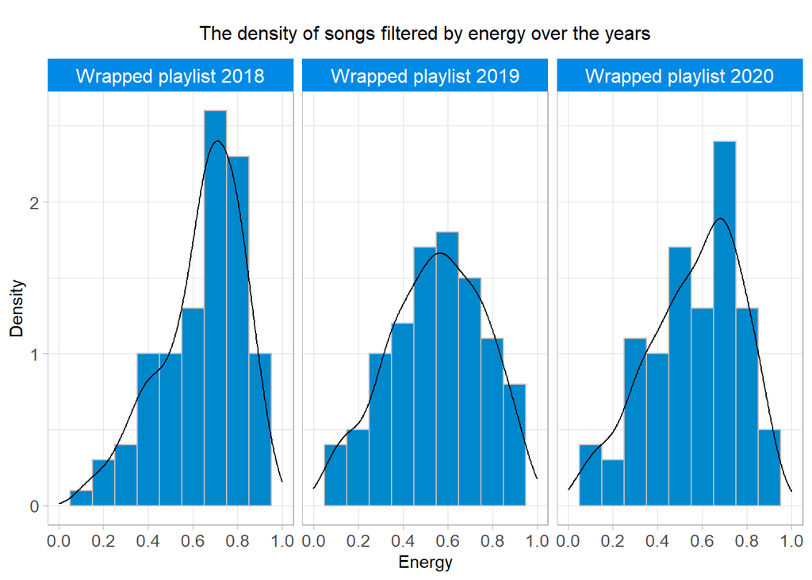

A scatterplot with the energy on the y axis and valence on the x so the mood of the songs can be compared.

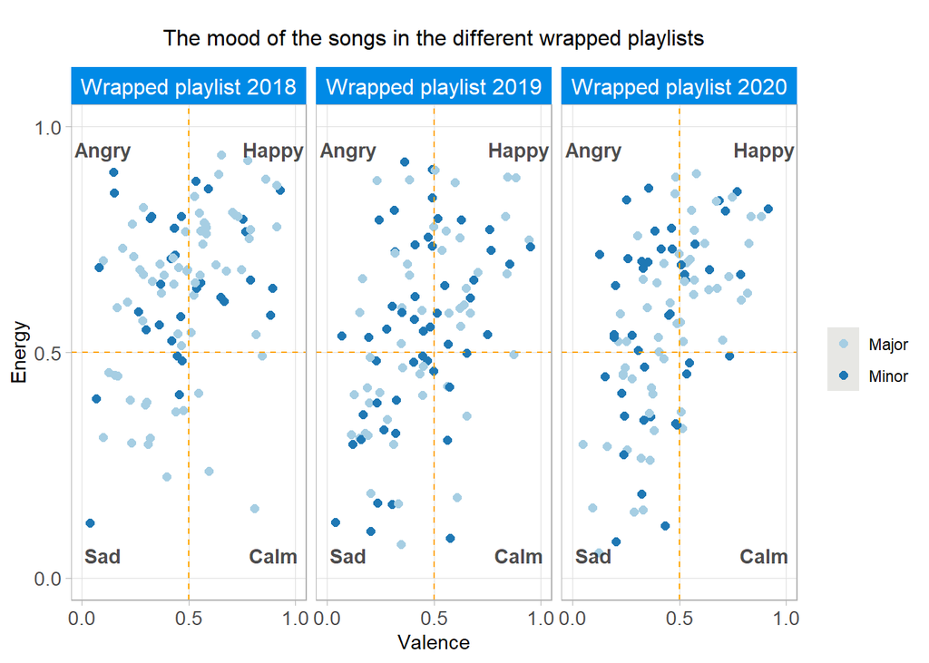

```r
combined %>%
  mutate(
    mode = ifelse(mode == 0, "Minor", "Major")
  ) %>%
  ggplot(                     # Set up the plot.
    aes(
      x = valence,
      y = energy,
      colour = mode
    )
  ) +
  geom_point(size = 2) +              # Scatter plot.

  facet_wrap(~category) +     # Separate charts per playlist.
  scale_x_continuous(         # Fine-tune the x axis.
    limits = c(0, 1),
    breaks = c(0, 0.5, 1),   # Use grid-lines for quadrants only.
    minor_breaks = NULL       # Remove 'minor' grid-lines.
  ) +
  scale_y_continuous(         # Fine-tune the y axis in the same way.
    limits = c(0, 1),
    breaks = c(0, 0.5, 1),
    minor_breaks = NULL
  ) +
  scale_colour_brewer(        # Use the Color Brewer to choose a palette.
    type = "qual",            # Qualitative set.
    palette = "Paired"        # Name of the palette is 'Paired'.
  ) +

  theme_light() +             # Use a simpler theme.
  labs(                       # Make the titles nice.
    x = "Valence",
    y = "Energy",
    colour = element_blank()
  ) +
  theme(
  axis.text = element_text(size = rel(0.95)),
  strip.background = element_rect(fill="#008ae6", size=1.5, linetype="solid"),
  strip.text = element_text(size = 12),
  plot.title = element_text(size=12,
    margin = margin(10, 0, 10, 0), hjust = 0.5),
  legend.key = element_rect(fill = "#e7e7e4")
) +
  annotate("text", x = 0.1, y = 0.05,
           label = "Sad" , color="black", alpha = 0.7, fontface="bold") +
  annotate("text", x = 0.1, y = 0.95,
           label = "Angry" , color="black", alpha = 0.7, fontface="bold") +
  annotate("text", x = 0.9, y = 0.05,
           label = "Calm" , color="black",alpha = 0.7, fontface="bold") +
  annotate("text", x = 0.9, y = 0.95,
           label = "Happy" , color="black", alpha = 0.7, fontface="bold") +
  ggtitle("The mood of the songs in the different wrapped playlists") +
    geom_hline(yintercept=0.5, linetype="dashed", color = "orange") +
  geom_vline(xintercept = 0.5, linetype="dashed",
                color = "orange")
```

An interesting find already is that there are not much calm songs in my Wrapped playlists, although i even have a separate playlist called ‘calm’ where i listen to all the time. Maybe my perception of calm song is different than that of spotify. I also wanted to see how much the influence of Billie Eilish is on the wrapped playlist of 2019 because 20 numbers are from her. That is shown in the scatter plot below. As expected most of her songs fall under the category ‘sad’.

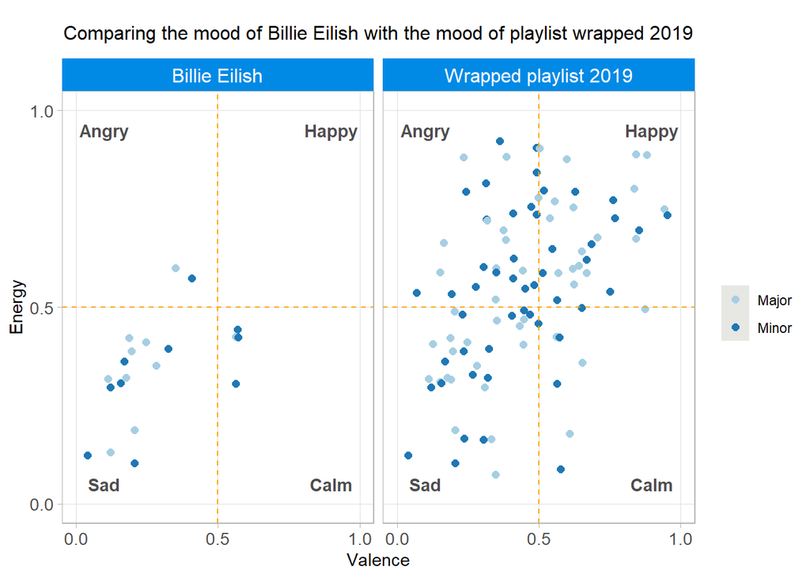

```r
billie %>%
  mutate(
    mode = ifelse(mode == 0, "Minor", "Major")
  ) %>%
  ggplot(                     # Set up the plot.
    aes(
      x = valence,
      y = energy,
      colour = mode
    )
  ) +
  geom_point(size = 2) +              # Scatter plot.

  facet_wrap(~category) +     # Separate charts per playlist.
  scale_x_continuous(         # Fine-tune the x axis.
    limits = c(0, 1),
    breaks = c(0, 0.5, 1),   # Use grid-lines for quadrants only.
    minor_breaks = NULL       # Remove 'minor' grid-lines.
  ) +
  scale_y_continuous(         # Fine-tune the y axis in the same way.
    limits = c(0, 1),
    breaks = c(0, 0.5, 1),
    minor_breaks = NULL
  ) +
  scale_colour_brewer(        # Use the Color Brewer to choose a palette.
    type = "qual",            # Qualitative set.
    palette = "Paired"        # Name of the palette is 'Paired'.
  ) +

  theme_light() +             # Use a simpler theme.
  labs(                       # Make the titles nice.
    x = "Valence",
    y = "Energy",
    colour = element_blank()
  ) +
  theme(
  axis.text = element_text(size = rel(0.95)),
  strip.background = element_rect(fill="#008ae6", size=1.5, linetype="solid"),
  strip.text = element_text(size = 12),
  plot.title = element_text(size=12,
    margin = margin(10, 0, 10, 0), hjust = 0.5),
  legend.key = element_rect(fill = "#e7e7e4")
) +
  annotate("text", x = 0.1, y = 0.05,
           label = "Sad" , color="black", alpha = 0.7, fontface="bold") +
  annotate("text", x = 0.1, y = 0.95,
           label = "Angry" , color="black", alpha = 0.7, fontface="bold") +
  annotate("text", x = 0.9, y = 0.05,
           label = "Calm" , color="black",alpha = 0.7, fontface="bold") +
  annotate("text", x = 0.9, y = 0.95,
           label = "Happy" , color="black", alpha = 0.7, fontface="bold") +
  ggtitle("Comparing the mood of Billie Eilish with the mood of playlist wrapped 2019") +
  geom_hline(yintercept=0.5, linetype="dashed", color = "orange") +
  geom_vline(xintercept = 0.5, linetype="dashed",
                color = "orange")
```